# Wrangle Doggos

Insights and visualisations

Data wrangling is often the most time consuming process in any data analysis project. But it is fundamental in achieving the goals of any project, which is to uncover solutions into real life problems based on data. After going through this process, the foundations are layed for the actual purpose of the project. Bellow I will list some of the questions which came into my mind when I first saw the available data set:

- Which dog stage is being favorited the most on average?
- Which dog stage is being retweeted the most on average?
- What is the average rating for all dog stages?

With these questions in mind, I was able to better asses and clean the data I had at my disposal, as well as to understand what other data needed to be gathered. Specifically, I had to pay close attention to the dog stages and I needed to be able to extract the correct ratings from the full_text.

```python
import pandas as pd
import numpy as np
import matplotlib.pyplot as plt

twitter_archive_master = pd.read_csv('twitter_archive_master.csv')
```

After reading the file with my wrangled data into a data frame, I am ready to explore the data and answer my questions. I will only select rows which have a dog stage.

```python
has_stage_archive = twitter_archive_master[twitter_archive_master['has_stage'] == 1]
for column in has_stage_archive.iloc[:,8:12].columns:
    avg_rating = has_stage_archive[has_stage_archive[column] == 1]['rating'].mean()
    print('The average rating for {}s is {}'.format(column, avg_rating))
```

```
The average rating for doggos is 1.104034582132565
The average rating for floofers is 1.1741935483870969
The average rating for puppers is 1.0551020408163265
The average rating for puppos is 1.2076923076923076
```

```python
for column in has_stage_archive.iloc[:,8:12].columns:
    avg_favorite_count = has_stage_archive[has_stage_archive[column] == 1]['favorite_count'].mean()
    print('The average favorite count for {}s is {}'.format(column, avg_favorite_count))
```

```
The average favorite count for doggos is 10518.550432276657
The average favorite count for floofers is 8333.935483870968
The average favorite count for puppers is 7696.836734693878
The average favorite count for puppos is 22847.26923076923
```

```python
for column in has_stage_archive.iloc[:,8:12].columns:
    avg_retweet_count = has_stage_archive[has_stage_archive[column] == 1]['retweet_count'].mean()
    print('The average retweet count for {}s is {}'.format(column, avg_retweet_count))
```

```
The average retweet count for doggos is 3483.9020172910664
The average retweet count for floofers is 2775.6451612903224
The average retweet count for puppers is 2278.195335276968
The average retweet count for puppos is 6545.038461538462
```

Of course, having a flat number for each dog stage is not very helpful. This state of affairs can definitely be improved with some visualisations. I believe a boxplot is a good choice in this situation, because it can show some of the spread within the data for each dog stage. Also, because the rating is on a completely arbitrary scale, I will only perform the visualisations for the favorite_count and retweet_count, and I will remove the top 10% of the values.

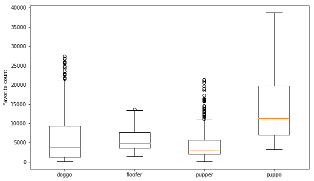

```python
doggos = has_stage_archive[has_stage_archive['doggo'] == 1]
floofers = has_stage_archive[has_stage_archive['floofer'] == 1]
puppers = has_stage_archive[has_stage_archive['pupper'] == 1]
puppos = has_stage_archive[has_stage_archive['puppo'] == 1]
dog_data = doggos[doggos['favorite_count'] < np.percentile(doggos['favorite_count'],90)]['favorite_count']
floof_data = floofers[floofers['favorite_count'] < np.percentile(floofers['favorite_count'],90)]['favorite_count']
pupper_data = puppers[puppers['favorite_count'] < np.percentile(puppers['favorite_count'],90)]['favorite_count']
puppo_data = puppos[puppos['favorite_count'] < np.percentile(puppos['favorite_count'],90)]['favorite_count']
fig, ax1 = plt.subplots(figsize=(10, 6))
ax1.set_ylabel('Favorite count')
plt.boxplot([dog_data,floof_data,pupper_data,puppo_data],labels=['doggo', 'floofer', 'pupper','puppo'])
plt.show()
```

[figure not shown]

```python
doggos = has_stage_archive[has_stage_archive['doggo'] == 1]
floofers = has_stage_archive[has_stage_archive['floofer'] == 1]
puppers = has_stage_archive[has_stage_archive['pupper'] == 1]
puppos = has_stage_archive[has_stage_archive['puppo'] == 1]
dog_data = doggos[doggos['favorite_count'] < np.percentile(doggos['retweet_count'],90)]['favorite_count']
floof_data = floofers[floofers['favorite_count'] < np.percentile(floofers['retweet_count'],90)]['favorite_count']
pupper_data = puppers[puppers['favorite_count'] < np.percentile(puppers['retweet_count'],90)]['favorite_count']
puppo_data = puppos[puppos['favorite_count'] < np.percentile(puppos['retweet_count'],90)]['favorite_count']
fig, ax1 = plt.subplots(figsize=(10, 6))
ax1.set_ylabel('Retweet count')
plt.boxplot([dog_data,floof_data,pupper_data,puppo_data],labels=['doggo', 'floofer', 'pupper','puppo'])
plt.show()
```

Of course, moving forwards, additional analysis can be done on this data set. These visualisations alone might be misleading , with them showing a clear difference between puppos and the other dog stages. In order to determine if the difference between the dog stages favorite_count and retwee_count are statistically relevant, a z-test can be performed, but not before transforming the data so that it has a normal distribution.